# Resultados UCLUST para secuencias del Genoma con id= 95, 97 y 99%

### UCLUST con id = 95, 97 y 99%

Estas graficas representan las secuencias de Genoma completo del virus del Dengue analizadas con UCLUST con id= 95, 97 y 99%.

De un total de 3884 datos con genoma completo:

- id 95% : 32 Secuencias disimilares
- id 97% : 98 Secuencias disimilares
- id 99% :745 Secuencias disilares

|  | N_Accesion | gi | Title | Serotype | Genotype | Gene | Size_sequence | Country | Location | Year | Month | lat_country | lon_country | locationtype_country | formatted_country | lat_location | lon_location | locationtype_location | formatted_location | Comments |
| --- | --- | --- | --- | --- | --- | --- | --- | --- | --- | --- | --- | --- | --- | --- | --- | --- | --- | --- | --- | --- |
| 1381 | FJ639670 | 221071158 | Dengue_virus_1_isolate_DENV_1_KH_BID_V1979_2001_complete_genome | DENV_1 | NA | Complete_Genome | 10693 | Cambodia | PHP | 2001 | NA | 12.565679 | 104.990963 | APPROXIMATE | Cambodia | NA | NA | NA | NA | Cambodia_PHP_cell_supernatant_2001_passage_history_AP61_passage_number_unknown_cohort_population_Dengue_Surveillance |
| 1293 | FJ461303 | 217302380 | Dengue_virus_1_isolate_DENV_1_VN_BID_V971_2007_complete_genome | DENV_1 | NA | Complete_Genome | 10691 | Viet Nam | South Viet Nam | 2007 | NA | 14.058324 | 108.277199 | APPROXIMATE | Vietnam | 14.058324 | 108.27720 | APPROXIMATE | Vietnam | Viet_Nam_South_plasma_2007_cohort_population_FG |
| 1124 | FJ384655 | 211908643 | Dengue_virus_1_isolate_DF01_HUB01021093_complete_genome | DENV_1 | NA | Complete_Genome | 10735 | Brazil | NA | NA | NA | -14.235004 | -51.925280 | APPROXIMATE | Brazil | NA | NA | NA | NA | Brazil_plasma |
| 2824 | KP723473 | 891070663 | Dengue_virus_1_isolate_DENV1_CN_GZ27_2014_complete_genome | DENV_1 | V | Complete_Genome | 10630 | China | Guangdong | 2014 | NA | 35.861660 | 104.195397 | APPROXIMATE | China | 23.379033 | 113.76328 | APPROXIMATE | Guangdong, China | V_China_Guangdong_2014 |
| 1086 | FJ196846 | 224551979 | Dengue_virus_1_isolate_GD95_95_polyprotein_gene_complete_cds | DENV_1 | NA | Complete_Genome | 10735 | China | Guangzhou | 1995 | NA | 35.861660 | 104.195397 | APPROXIMATE | China | 23.129110 | 113.26439 | APPROXIMATE | Guangzhou, Guangdong, China | China_Guangzhou_Guangdong_Province_cell_culture_from_Aedes_albopictus_cell_line__C6_36__1995 |
| 963 | EU848545 | 194338412 | Dengue_virus_1_isolate_US_Hawaii_1944_complete_genome | DENV_1 | NA | Complete_Genome | 10734 | United States | Hawaii | 1944 | NA | 37.090240 | -95.712891 | APPROXIMATE | United States | 19.896766 | -155.58278 | APPROXIMATE | Hawaii, USA | USA_Hawaii_pooled_serum_from_6_patients_mouse_adapted_1944 |
| 236 | EF457905 | 148828518 | Dengue_virus_type_1_isolate_P72_1244_complete_genome | DENV_1 | NA | Complete_Genome | 10735 | Malaysia | NA | 1972 | NA | 4.210484 | 101.975766 | APPROXIMATE | Malaysia | NA | NA | NA | NA | Malaysia_1972 |
| 3582 | KF184975 | 544370125 | Dengue_virus_1_isolate_Angola_2013_polyprotein_gene_complete_cds | DENV_1 | NA | Complete_Genome | 10602 | Angola | NA | 2013 | Apr | -11.202692 | 17.873887 | APPROXIMATE | Angola | NA | NA | NA | NA | Angola_serum_Apr_2013 |
| 3658 | JQ922547 | 428624551 | Dengue_virus_1_isolate_DENV_1_THAI_606147_1960_complete_genome | DENV_1 | NA | Complete_Genome | 10395 | Thailand | NA | 1960 | NA | 15.870032 | 100.992541 | APPROXIMATE | Thailand | NA | NA | NA | NA | Thailand_1960 |
| 2028 | LC128301 | 1001622301 | Dengue_virus_1_genomic_RNA_complete_sequence_strain:_D1_Hu_Philippines_NIID13_2016 | DENV_1 | NA | Complete_Genome | 10693 | Philippines | NA | 2016 | NA | 12.879721 | 121.774017 | APPROXIMATE | Philippines | NA | NA | NA | NA | Philippines_serum_of_patient_2016_01 |

[output cut: 22 more lines]

**Tabla 1.** Datos de secuencias del genoma 95% disimilares.

|  | N_Accesion | gi | Title | Serotype | Genotype | Gene | Size_sequence | Country | Location | Year | Month | lat_country | lon_country | locationtype_country | formatted_country | lat_location | lon_location | locationtype_location | formatted_location | Comments |
| --- | --- | --- | --- | --- | --- | --- | --- | --- | --- | --- | --- | --- | --- | --- | --- | --- | --- | --- | --- | --- |
| 1381 | FJ639670 | 221071158 | Dengue_virus_1_isolate_DENV_1_KH_BID_V1979_2001_complete_genome | DENV_1 | NA | Complete_Genome | 10693 | Cambodia | PHP | 2001 | NA | 12.565679 | 104.990963 | APPROXIMATE | Cambodia | NA | NA | NA | NA | Cambodia_PHP_cell_supernatant_2001_passage_history_AP61_passage_number_unknown_cohort_population_Dengue_Surveillance |
| 1293 | FJ461303 | 217302380 | Dengue_virus_1_isolate_DENV_1_VN_BID_V971_2007_complete_genome | DENV_1 | NA | Complete_Genome | 10691 | Viet Nam | South Viet Nam | 2007 | NA | 14.058324 | 108.277199 | APPROXIMATE | Vietnam | 14.058324 | 108.277199 | APPROXIMATE | Vietnam | Viet_Nam_South_plasma_2007_cohort_population_FG |
| 1124 | FJ384655 | 211908643 | Dengue_virus_1_isolate_DF01_HUB01021093_complete_genome | DENV_1 | NA | Complete_Genome | 10735 | Brazil | NA | NA | NA | -14.235004 | -51.925280 | APPROXIMATE | Brazil | NA | NA | NA | NA | Brazil_plasma |
| 2819 | KF289073 | 613790718 | Dengue_virus_1_isolate_P23086_complete_genome | DENV_1 | NA | Complete_Genome | 10690 | India | NA | 1956 | NA | 20.593684 | 78.962880 | APPROXIMATE | India | NA | NA | NA | NA | India_1956 |
| 2824 | KP723473 | 891070663 | Dengue_virus_1_isolate_DENV1_CN_GZ27_2014_complete_genome | DENV_1 | V | Complete_Genome | 10630 | China | Guangdong | 2014 | NA | 35.861660 | 104.195397 | APPROXIMATE | China | 23.379033 | 113.763283 | APPROXIMATE | Guangdong, China | V_China_Guangdong_2014 |
| 1087 | FJ196847 | 224551981 | Dengue_virus_1_isolate_GD01_97_polyprotein_gene_complete_cds | DENV_1 | NA | Complete_Genome | 10735 | China | Guangzhou | 1997 | NA | 35.861660 | 104.195397 | APPROXIMATE | China | 23.129110 | 113.264385 | APPROXIMATE | Guangzhou, Guangdong, China | China_Guangzhou_Guangdong_Province_cell_culture_from_Aedes_albopictus_cell_line__C6_36__1997 |
| 1086 | FJ196846 | 224551979 | Dengue_virus_1_isolate_GD95_95_polyprotein_gene_complete_cds | DENV_1 | NA | Complete_Genome | 10735 | China | Guangzhou | 1995 | NA | 35.861660 | 104.195397 | APPROXIMATE | China | 23.129110 | 113.264385 | APPROXIMATE | Guangzhou, Guangdong, China | China_Guangzhou_Guangdong_Province_cell_culture_from_Aedes_albopictus_cell_line__C6_36__1995 |
| 1085 | FJ196845 | 224551977 | Dengue_virus_1_isolate_GD03_91_polyprotein_gene_complete_cds | DENV_1 | NA | Complete_Genome | 10735 | China | Guangzhou | 1991 | NA | 35.861660 | 104.195397 | APPROXIMATE | China | 23.129110 | 113.264385 | APPROXIMATE | Guangzhou, Guangdong, China | China_Guangzhou_Guangdong_Province_cell_culture_from_Aedes_albopictus_cell_line__C6_36__1991 |
| 1082 | FJ196842 | 224551971 | Dengue_virus_1_isolate_GD66_03_polyprotein_gene_complete_cds | DENV_1 | NA | Complete_Genome | 10735 | China | Guangzhou | 2003 | NA | 35.861660 | 104.195397 | APPROXIMATE | China | 23.129110 | 113.264385 | APPROXIMATE | Guangzhou, Guangdong, China | China_Guangzhou_Guangdong_Province_cell_culture_from_Aedes_albopictus_cell_line__C6_36__2003 |
| 2265 | GU131863 | 263612994 | Dengue_virus_1_isolate_DENV_1_BR_BID_V3490_2008_complete_genome | DENV_1 | NA | Complete_Genome | 10532 | Brazil | Sao Paulo | 2008 | NA | -14.235004 | -51.925280 | APPROXIMATE | Brazil | -23.550520 | -46.633309 | APPROXIMATE | São Paulo, State of São Paulo, Brazil | Brazil_Sao_Paulo_serum_2008_cohort_population_RP_BR |

[output cut: 88 more lines]

**Tabla 2.** Datos de secuencias del genoma 97% disimilares.

|  | N_Accesion | gi | Title | Serotype | Genotype | Gene | Size_sequence | Country | Location | Year | Month | lat_country | lon_country | locationtype_country | formatted_country | lat_location | lon_location | locationtype_location | formatted_location | Comments |
| --- | --- | --- | --- | --- | --- | --- | --- | --- | --- | --- | --- | --- | --- | --- | --- | --- | --- | --- | --- | --- |
| 1381 | FJ639670 | 221071158 | Dengue_virus_1_isolate_DENV_1_KH_BID_V1979_2001_complete_genome | DENV_1 | NA | Complete_Genome | 10693 | Cambodia | PHP | 2001 | NA | 12.565679 | 104.990963 | APPROXIMATE | Cambodia | NA | NA | NA | NA | Cambodia_PHP_cell_supernatant_2001_passage_history_AP61_passage_number_unknown_cohort_population_Dengue_Surveillance |
| 3784 | JF937615 | 332959477 | Dengue_virus_1_isolate_DENV_1_VN_BID_V4062_2008_complete_genome | DENV_1 | NA | Complete_Genome | 10448 | Viet Nam | South Viet Nam | 2008 | NA | 14.058324 | 108.277199 | APPROXIMATE | Vietnam | 14.058324 | 108.277199 | APPROXIMATE | Vietnam | Viet_Nam_South_plasma_2008_cohort_population_MD |
| 98 | AY708047 | 56698931 | Dengue_virus_type_1_strain_D1Myanmar059_01_polyprotein_gene_complete_cds | DENV_1 | NA | Complete_Genome | 10614 | Myanmar | NA | NA | NA | 21.916221 | 95.955974 | APPROXIMATE | Myanmar (Burma) | NA | NA | NA | NA | Myanmar |
| 1293 | FJ461303 | 217302380 | Dengue_virus_1_isolate_DENV_1_VN_BID_V971_2007_complete_genome | DENV_1 | NA | Complete_Genome | 10691 | Viet Nam | South Viet Nam | 2007 | NA | 14.058324 | 108.277199 | APPROXIMATE | Vietnam | 14.058324 | 108.277199 | APPROXIMATE | Vietnam | Viet_Nam_South_plasma_2007_cohort_population_FG |
| 1124 | FJ384655 | 211908643 | Dengue_virus_1_isolate_DF01_HUB01021093_complete_genome | DENV_1 | NA | Complete_Genome | 10735 | Brazil | NA | NA | NA | -14.235004 | -51.925280 | APPROXIMATE | Brazil | NA | NA | NA | NA | Brazil_plasma |
| 2810 | FJ898396 | 228540033 | Dengue_virus_1_isolate_DENV_1_VN_BID_V2858_2006_complete_genome | DENV_1 | NA | Complete_Genome | 10719 | Viet Nam | South Viet Nam | 2006 | NA | 14.058324 | 108.277199 | APPROXIMATE | Vietnam | 14.058324 | 108.277199 | APPROXIMATE | Vietnam | Viet_Nam_South_plasma_2006_cohort_population_MD |
| 1114 | FJ373297 | 209976517 | Dengue_virus_1_isolate_DENV_1_VN_BID_V1647_2007_complete_genome | DENV_1 | NA | Complete_Genome | 10690 | Viet Nam | South Viet Nam | 2007 | NA | 14.058324 | 108.277199 | APPROXIMATE | Vietnam | 14.058324 | 108.277199 | APPROXIMATE | Vietnam | Viet_Nam_South_plasma_2007_cohort_population_FG |
| 1147 | FJ410175 | 209976601 | Dengue_virus_1_isolate_DENV_1_US_BID_V2095_1994_complete_genome | DENV_1 | NA | Complete_Genome | 10690 | Puerto Rico | NA | 1994 | NA | 18.220833 | -66.590149 | APPROXIMATE | Puerto Rico | NA | NA | NA | NA | USA_Puerto_Rico_cell_supernatant_1994_passage_history_C6_36_1_cohort_population_Puerto_Rico |
| 2796 | FJ898410 | 228540452 | Dengue_virus_1_isolate_DENV_1_VN_BID_V2888_2006_complete_genome | DENV_1 | NA | Complete_Genome | 10690 | Viet Nam | South Viet Nam | 2006 | NA | 14.058324 | 108.277199 | APPROXIMATE | Vietnam | 14.058324 | 108.277199 | APPROXIMATE | Vietnam | Viet_Nam_South_plasma_2006_cohort_population_MD |
| 1765 | GU370049 | 289187578 | Dengue_virus_1_isolate_SGEHI_D1_1494Y08_polyprotein_gene_complete_cds | DENV_1 | NA | Complete_Genome | 10564 | Singapore | NA | 2008 | Sep | 1.352083 | 103.819836 | APPROXIMATE | Singapore | NA | NA | NA | NA | Singapore_serum_Sep_2008_passaged_in_C6_36_cells |

[output cut: 735 more lines]

**Tabla 3.** Datos de secuencias del genoma 99% disimilares.

### Serotipos

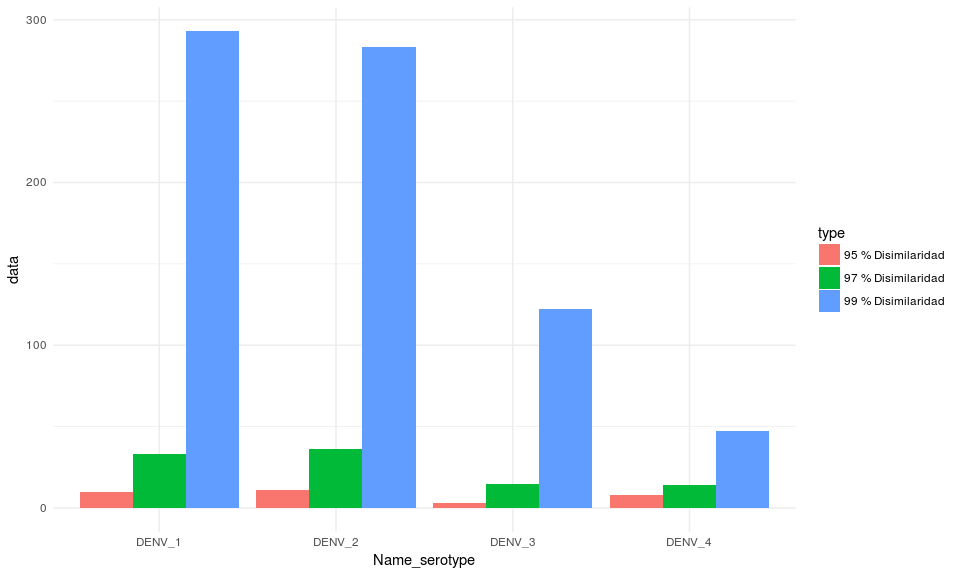

**Figura 1.** Numero de datos por serotipos para las secuencias Disimilares al 95, 97 y 99%

### Paises

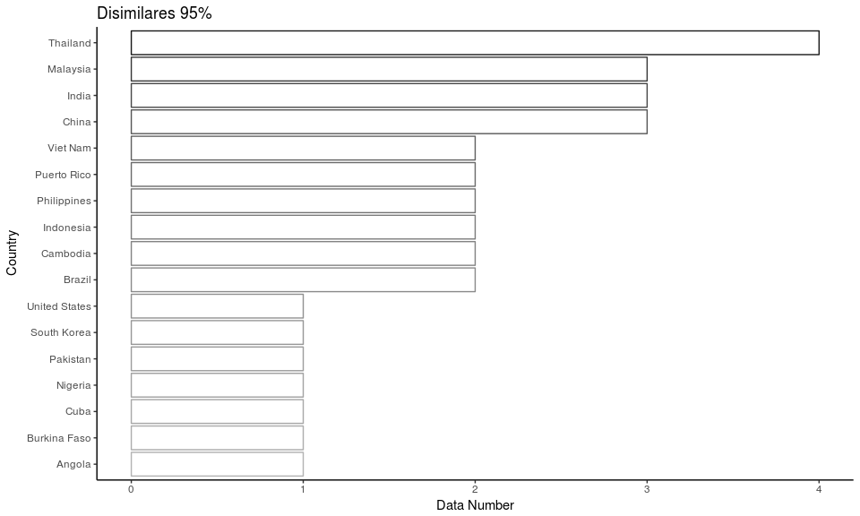

**Figura 2.** Paises para secuencias de Genoma 95% disimilares.

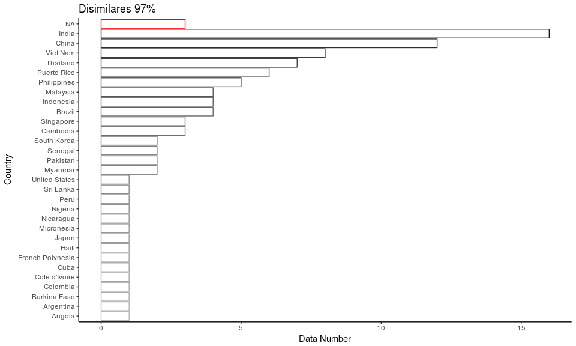

**Figura 3.** Paises para secuencias de Genoma 97% disimilares.

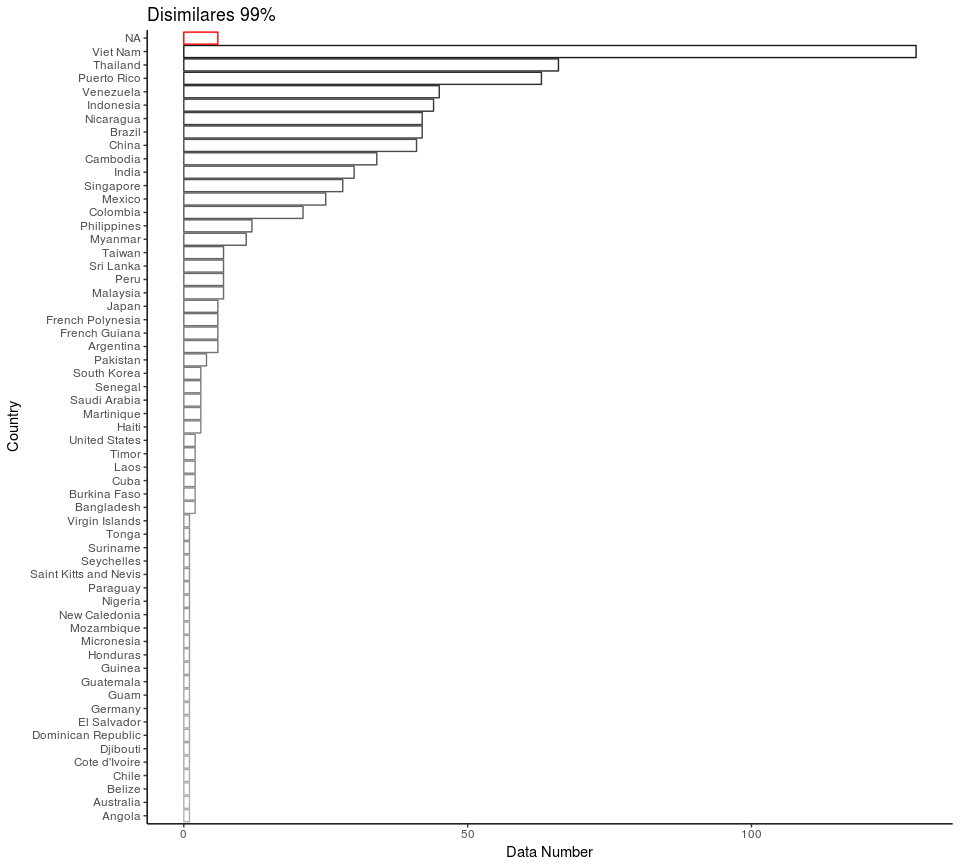

**Figura 4.** Paises para secuencias de Genoma 99% disimilares.

### Mapa-Mundi: Numero de casos reportados por paises

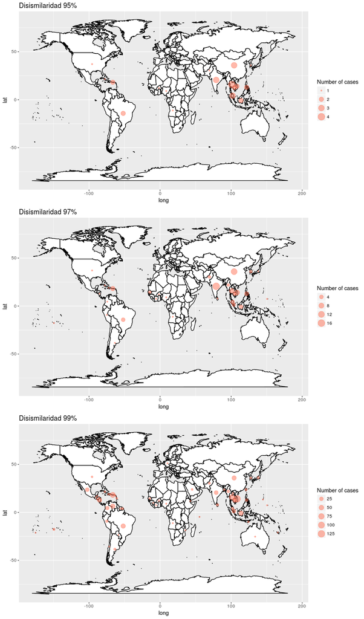

**Figura 5.** Numero de casos reportados por paises.

### Mapa-mundi: Serotipos por paises

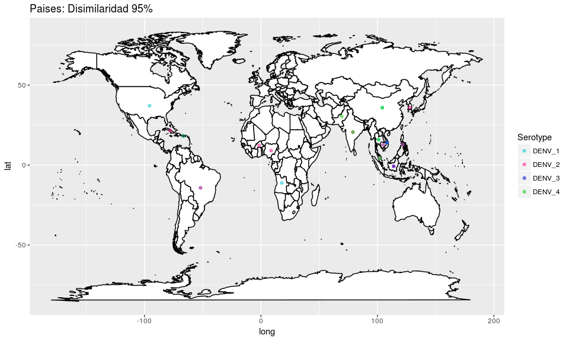

**Figura 6.** Distribucion de los serotipos por paises para secuencias 95% disimilares.

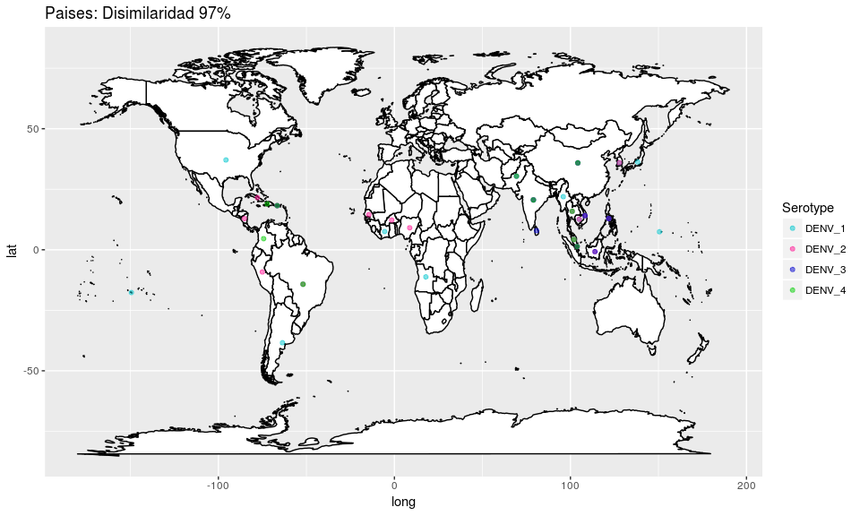

**Figura 7.** Distribucion de los serotipos por paises para secuencias 97% disimilares.

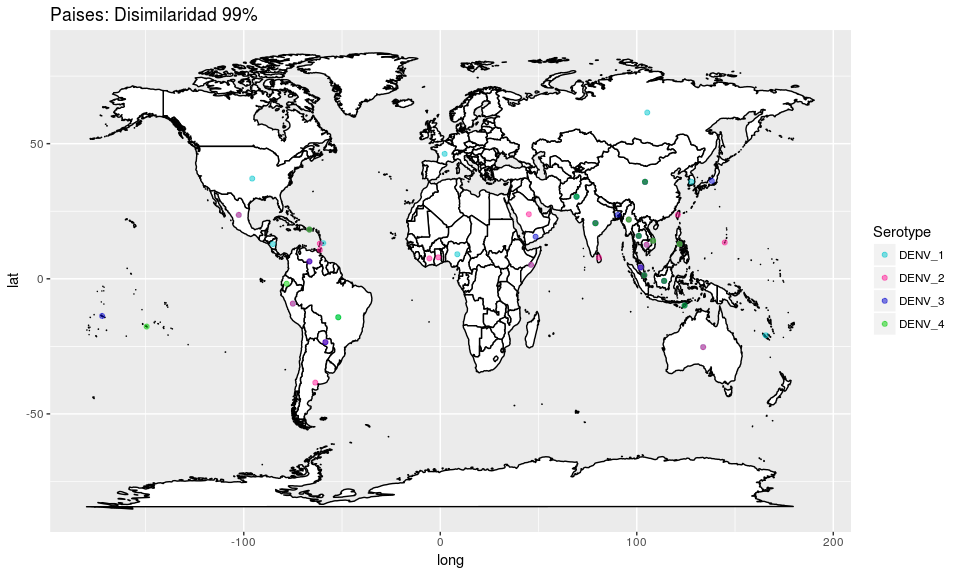

**Figura 8.** Distribucion de los serotipos por paises para secuencias 99% disimilares.

### Localidades: Disimilaridad 95%

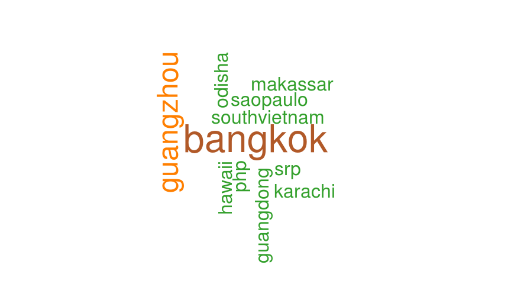

**Figura 9.** Nube de localidades para secuecias del Genoma 95% Disimilares.

### Localidades: Disimilaridad 97%

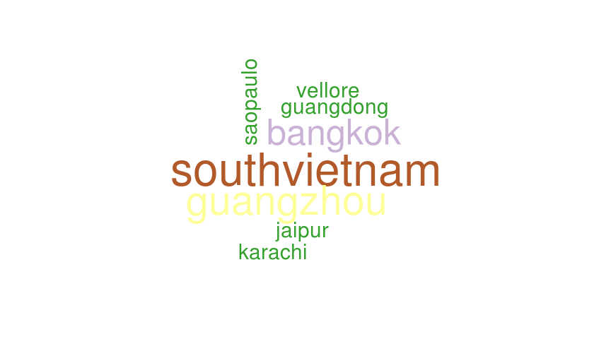

**Figura 10.** Nube de localidades para secuecias del Genoma 97% Disimilares.

### Localidades: Disimilaridad 99%

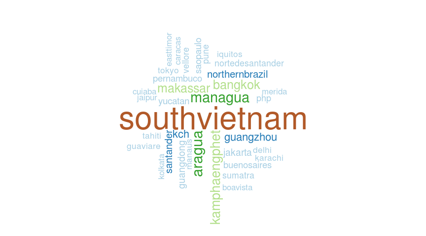

**Figura 11.** Nube de localidades para secuecias del Genoma 99% Disimilares.

### Mapa-mundi localidades 95% Disimilaridad

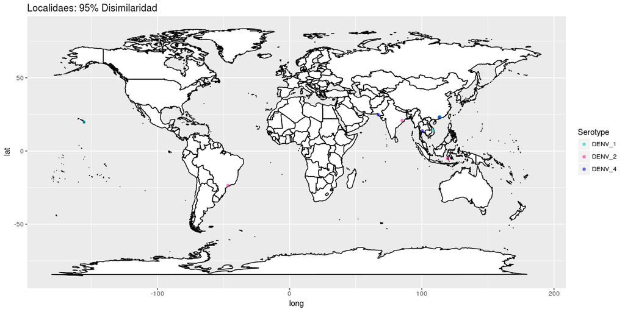

**Figura 12.** Localidades de secuencias del genoma 95% disimilares.

### Mapa-mundi localidades 97% Disimilaridad

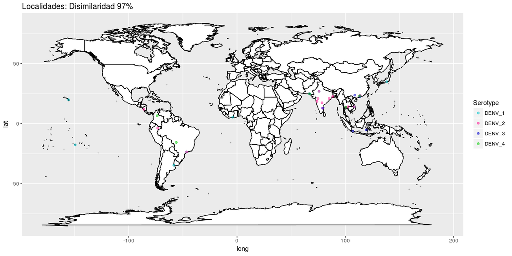

**Figura 13.** Localidades de secuencias del genoma 97% disimilares.

### Mapa-mundi localidades 99% Disimilaridad

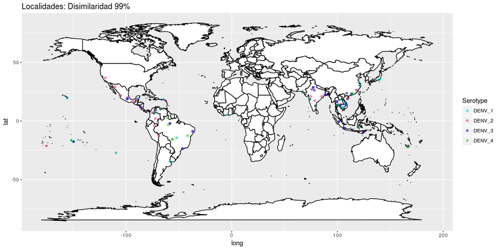

**Figura 14.** Localidades de secuencias del genoma 99% disimilares.

### Años: Disimilaridad 95%

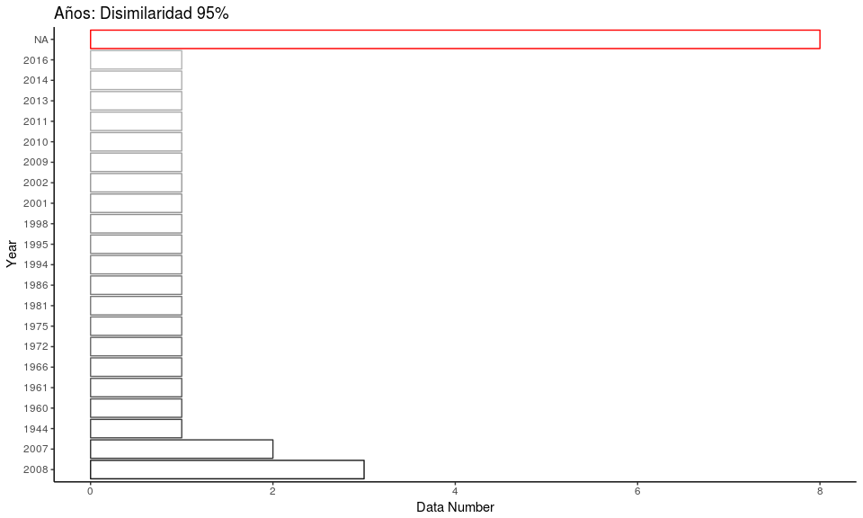

**Figura 15.** Años registrados para casos con secuencias 95% disimilares.

### Años: Disimilaridad 97%

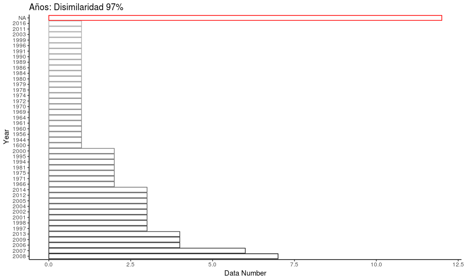

**Figura 16.** Años registrados para casos con secuencias 97% disimilares.

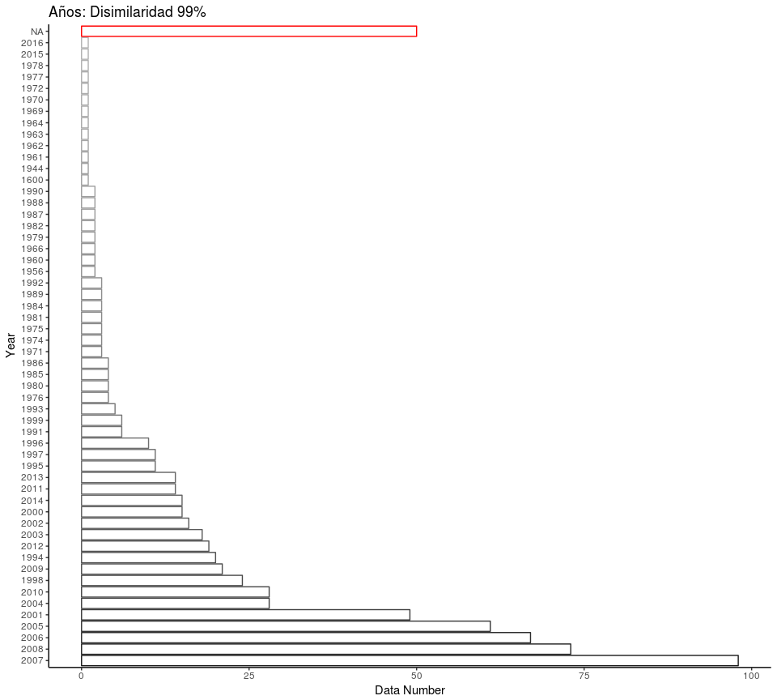

**Figura 17.** Años registrados para casos con secuencias 99% disimilares.

### Frecuencia de los años reportados por cada pais: Disimilaridad 95%

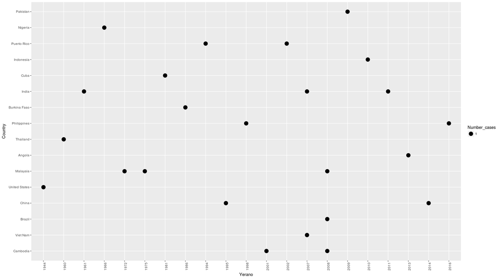

**Figura 18.** Frecuencia de los años reportados para cada pais para secuencias 95% disimilaridad.

### Frecuencia de los años reportados por cada pais: Disimilaridad 97%

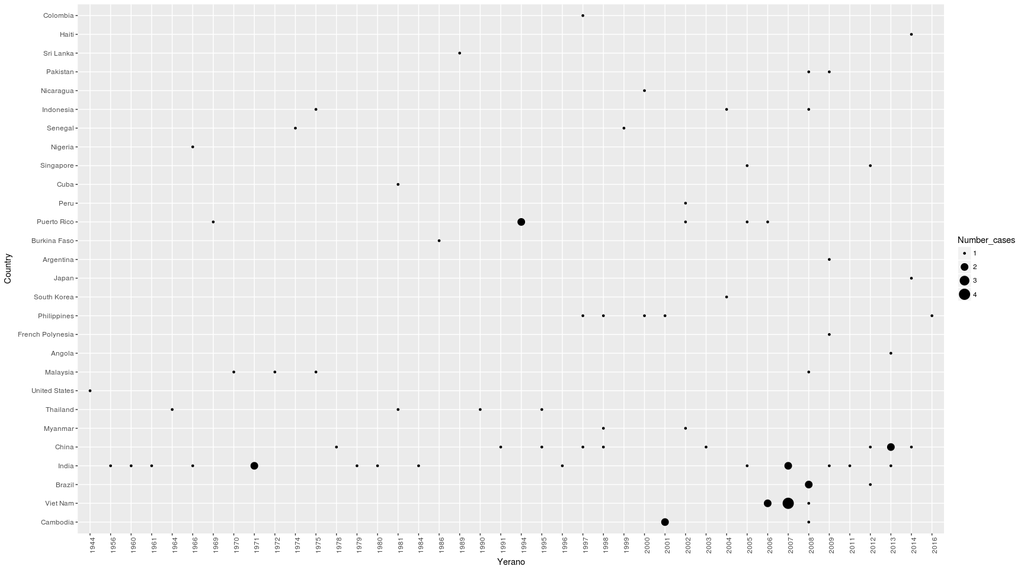

**Figura 19.** Frecuencia de los años reportados para cada pais para secuencias 97% disimilaridad.

### Frecuencia de los años reportados por cada pais: Disimilaridad 99%

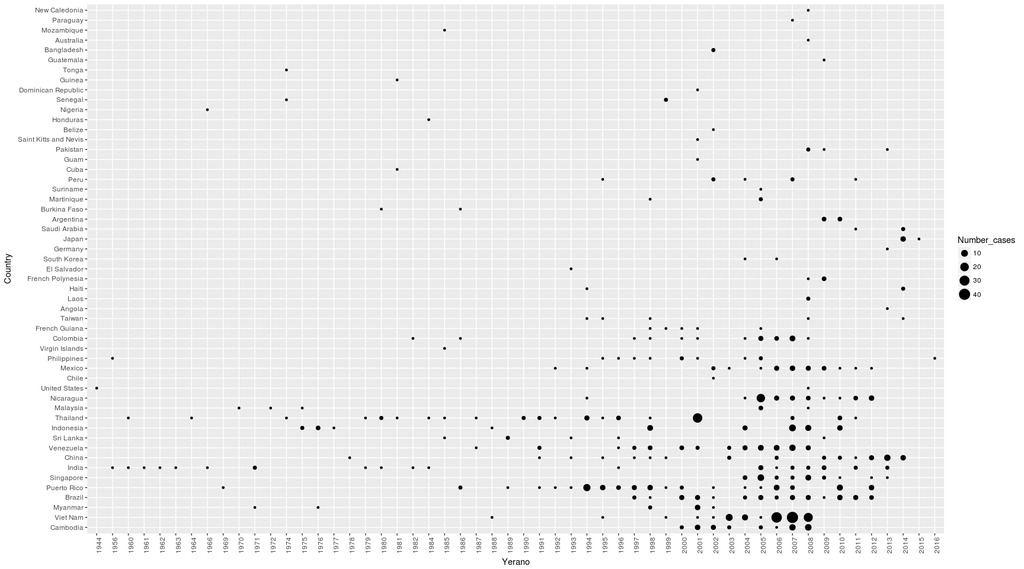

**Figura 20.** Frecuencia de los años reportados para cada pais para secuencias 99% disimilaridad.

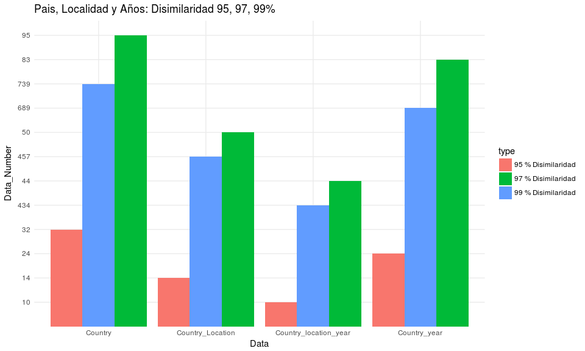

**Figura 21.** Frecuencia de los datos con disimilaridad del 95, 97 y 99% que contienen: 1. Pais, 2. Pais y Localidad, 3. Pais, Localidad y año, 4. Pais y año.